# Data Analysis

## LRR correlations

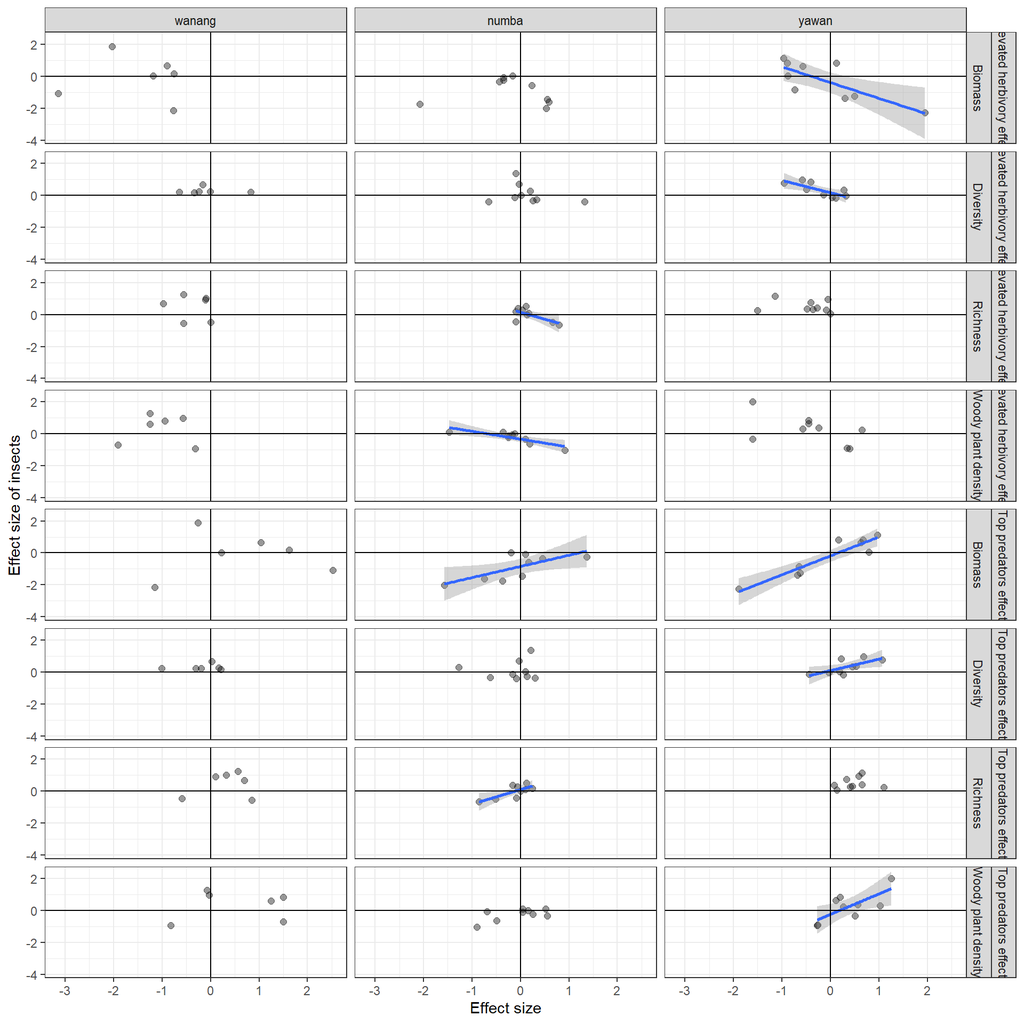

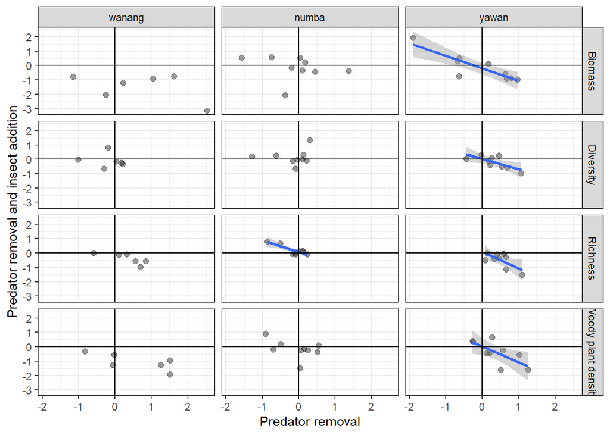

From the figure we see that there is usually no correlation in Wanang and Numba but it is always present in Yawan. Moreover it is not positive but negative. This means that when we observer negative effect of predator removal on biomass we can expect to have positive effect of insect addition to the exclosure. In cases where the effect of predators is positive, we would get a negative effect of insect addition.

### Fungi vs insect correlation

No correlation should be observed in case of compensatory effect In case of species richness only effects of insect, herbivore addition and herbivore removal were correlated. Herbivore addition and removal were negatively correlated as expected. If there is a compensatory effect there should be no correlation (because when we remove one factor the other takes over and equalize the effect). Positive correlation rules out compensation. A positive correlations would suggest bottom-up control.

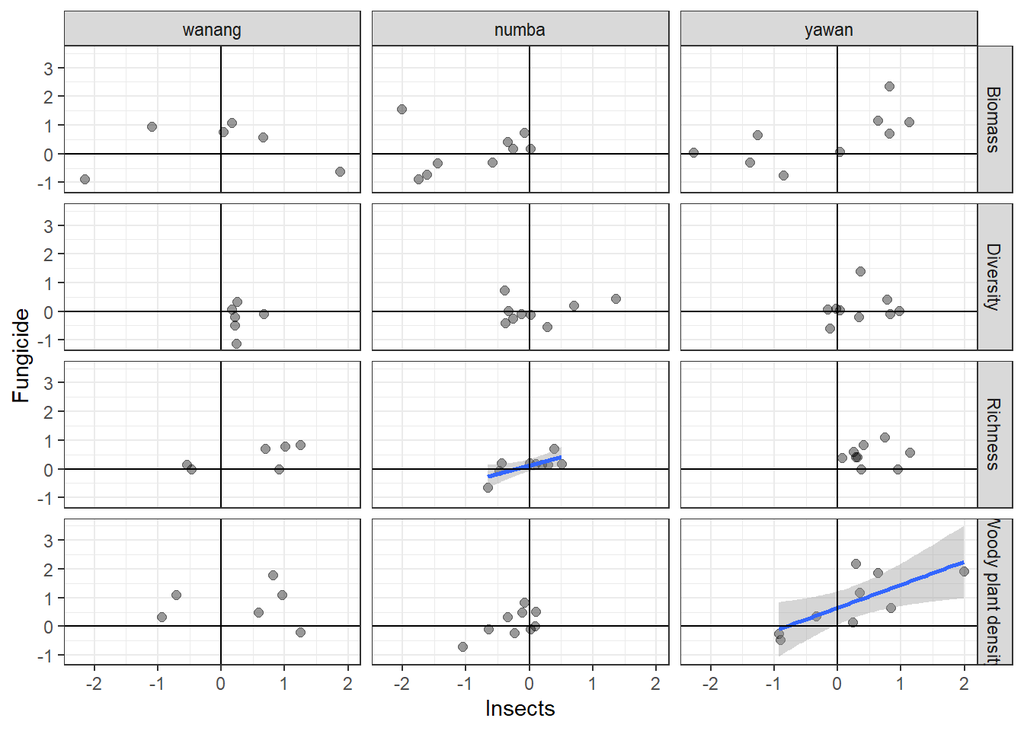

Figure 2. Log-Response Ratio correlations for insects and fungi effects on bimoass, diversity adn density of woody plants

## COMMUNITY COMPOSITION

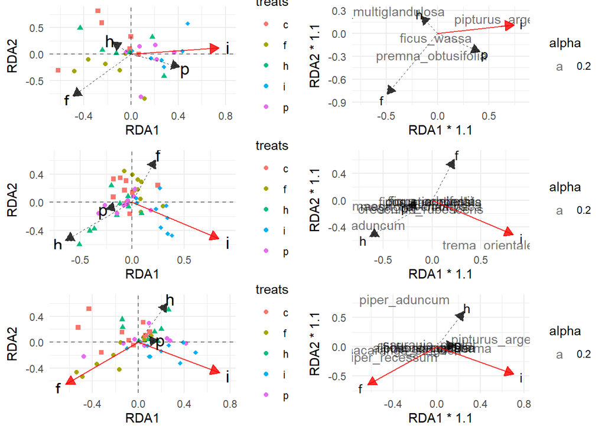

### Bray-Curtis dissimilarity

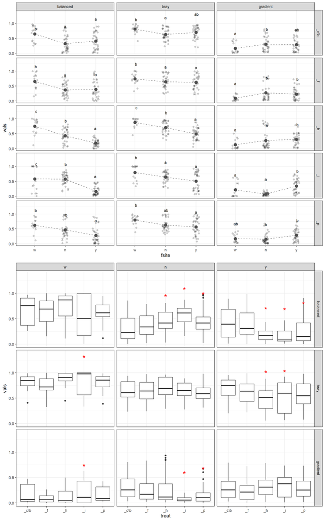

## Are changes random or deterministic for different treatments?

At the highest studied elevation (Yawan) all treatment caused a shift from composition being deterministic in their divergence (predictably unpredictable to random). Similar shift, but weaker in cases of insecticide and fungicide was observed for Wanang. Strikingly different assembly was observed for Numba, where communities showed rather random assembly and only addition of herbivores increased divergence of the community composition.

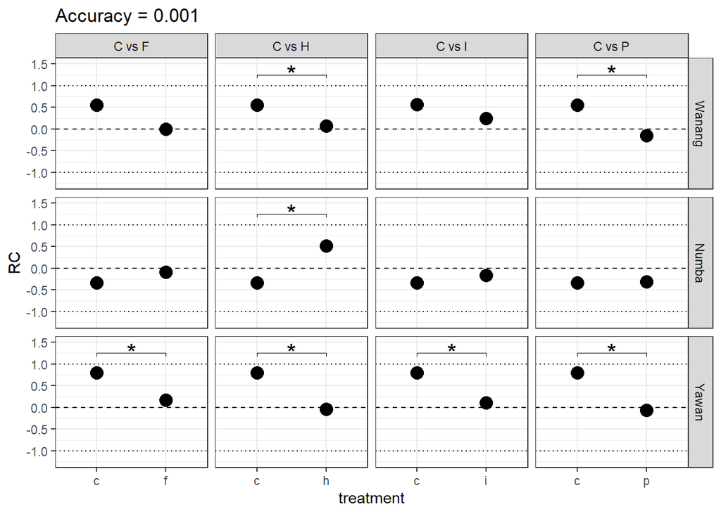

Making sense out of the above:

- Insects shape community composition at all elevations. Fungi affected community composition only in Yawan. Fungi increase the species richness, without affecting any other characteristics of the community (beta-diversity components). Whereas in Wanang despite having effect on richness and density the effects on the community composition was not visible possibly because of high baseline dissimilarity (variability in community composition) between sites. NUmba seems to be specific. Despite the effect being present they are being balanced in a way that left the community characteristics unchanged.
- Insect herbivores (P, I, H combined) can suppress plants in communities with low variability in species composition, which allows for new species to establish. Moreover, **insects reduce dissimilarity for highly variable communities** (is this true?). Exclusion of top predators has the same effect as insect exclusion on species turnover in Numba and Yawan. This is a probable result for a strong top-down control of the tri-trophic interactions. Addition of generalist herbivores also correlated with the predator effects. If the effects of insects are mainly caused by specialists, then generalists interfering with their feeding could have the same results. But the effects can be more subtle than those of herbivore removal.

### Traits and species faith

In this section we focus on plant species traits and how these can help us predict the performance of individual species at a given plot. First we attempt to predict simply whether a species, considering it’s traits, will be lost, gained or will remain in various treatment plots. We used random forest to investigate the importance of traits in predicting the species faith. Prediction accuracy and classifier_RF will tell us how good well the set of traits is (and which traits are most important in predicting faith) for the faith of individuals.

I perform the sane analyses for each treatment.

Let us now move to test SLA ability to predict the biomass of an individual. This is a bit tricky because we will use SLA estimated at the end of the experiment. From the leaf frame analyses that spanned all plant species in all treatment plots we saw high plasticity of that trait.

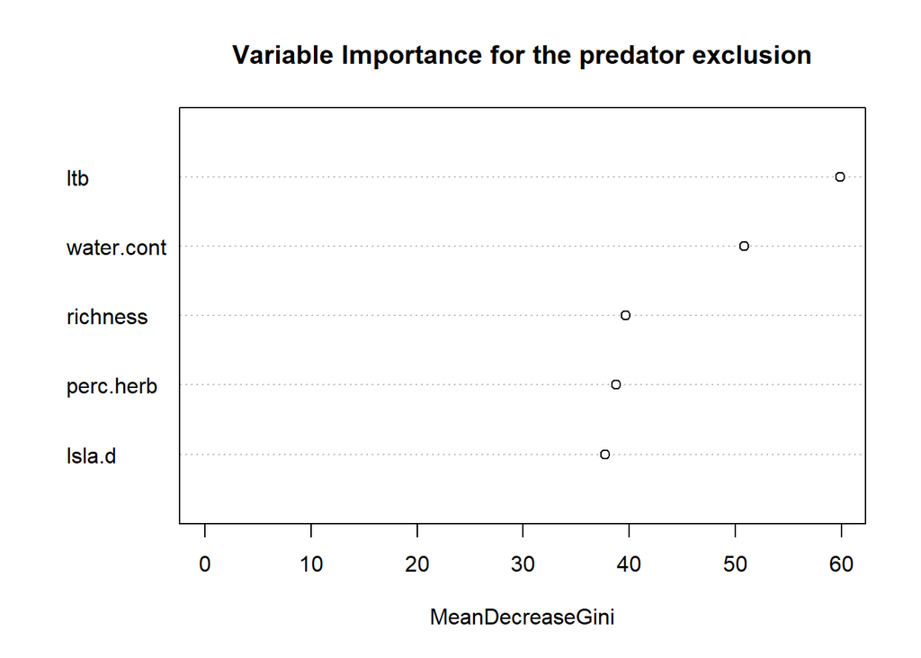

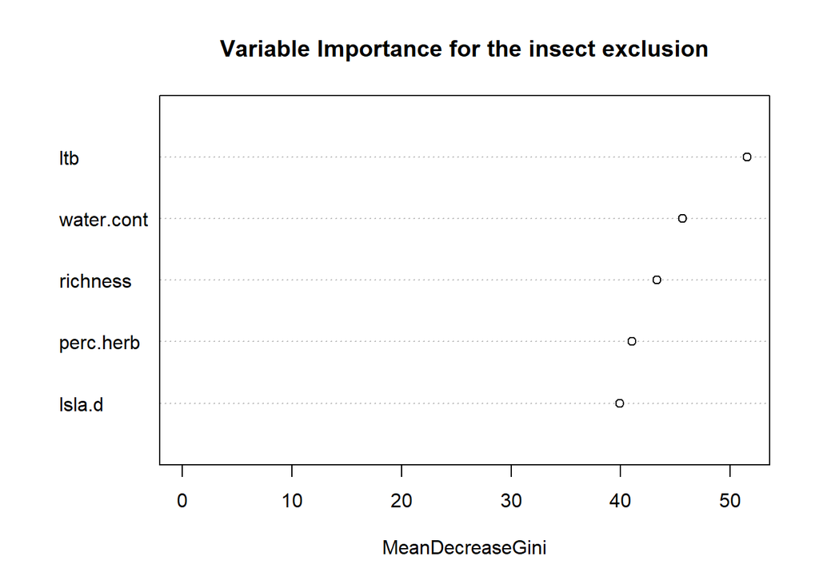

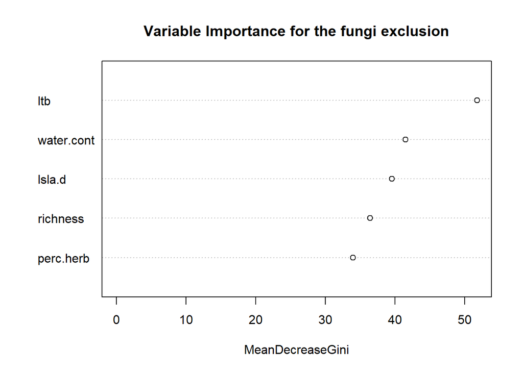

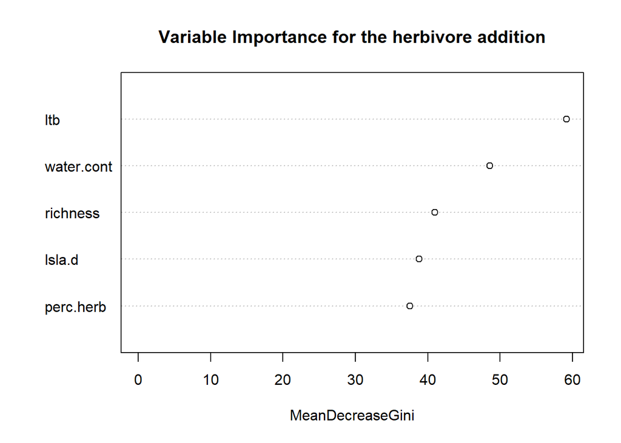